# NYC Housing Analysis

2026-02-18

## Libraries & Data

```r
library(dplyr)
library(faraway)
library(tidyverse)
library(janitor)
library(caret)
library(tidyr)
library(caTools)
library(Information)
library(car)
library(stats)
library(corrplot)
library(patchwork)
library(GGally)
library(leaps)
library(MASS)
```

```r
nyc <- read.csv("nyc_housing_base.csv")

glimpse(nyc)
```

```
## Rows: 34,439
## Columns: 19
## $ borough_x    <int> 1, 1, 1, 1, 1, 1, 1, 1, 1, 1, 1, 1, 1, 1, 1, 1, 1, 1, 1, …
## $ block        <int> 400, 402, 402, 404, 372, 373, 373, 374, 375, 376, 376, 37…
## $ lot          <int> 11, 36, 60, 42, 55, 46, 46, 8, 30, 5, 5, 13, 31, 62, 67, …
## $ sale_price   <int> 280000, 2000000, 3400000, 4000000, 655000, 470000, 474000…
## $ zip_code     <dbl> 10009, 10009, 10009, 10009, 10009, 10009, 10009, 10009, 1…
## $ borough_y    <chr> "MN", "MN", "MN", "MN", "MN", "SI", "SI", "BK", "MN", "MN…
## $ yearbuilt    <dbl> 1900, 1900, 1920, 1855, 1920, 1944, 1944, 1899, 1902, 190…
## $ lotarea      <dbl> 2404, 1919, 2150, 2369, 5298, 3132, 3132, 1400, 3082, 377…
## $ bldgarea     <dbl> 6875, 7810, 6152, 6990, 17990, 2440, 2440, 2700, 17556, 1…
## $ resarea      <dbl> 6875, 6810, 5352, 6990, 17990, 440, 440, 2700, 17556, 140…
## $ comarea      <dbl> 0, 1000, 800, 0, 0, 2000, 2000, 0, 0, 1000, 1000, 0, 0, 0…
## $ unitsres     <dbl> 18, 8, 8, 10, 20, 1, 1, 3, 19, 22, 22, 5, 19, 13, 17, 16,…
## $ unitstotal   <dbl> 18, 10, 9, 10, 20, 2, 2, 3, 19, 24, 24, 5, 19, 13, 17, 18…
## $ numfloors    <dbl> 5, 5, 5, 5, 5, 2, 2, 3, 6, 6, 6, 3, 6, 6, 6, 6, 6, 6, 6, …
## $ latitude     <dbl> 40.72442, 40.72497, 40.72535, 40.72740, 40.72062, 40.6131…
## $ longitude    <dbl> -73.98389, -73.98154, -73.98311, -73.98060, -73.97953, -7…
## $ landuse      <dbl> 2, 2, 4, 2, 2, 4, 4, 2, 2, 2, 2, 2, 2, 2, 2, 2, 2, 2, 2, …
## $ bldgclass    <chr> "C6", "C4", "C7", "C4", "C6", "K4", "K4", "C0", "C6", "C6…
## $ building_age <dbl> 125, 125, 105, 170, 105, 81, 81, 126, 123, 125, 125, 117,…
```

## Q1: EDA Part 1 — Individual Variables

### Residential Area

Log scale is used here to better visualize the spread of a heavily right-skewed variable. Each step on the axis represents a multiplying factor rather than a fixed increment, which allows us to see the full distribution without the large values compressing everything else.

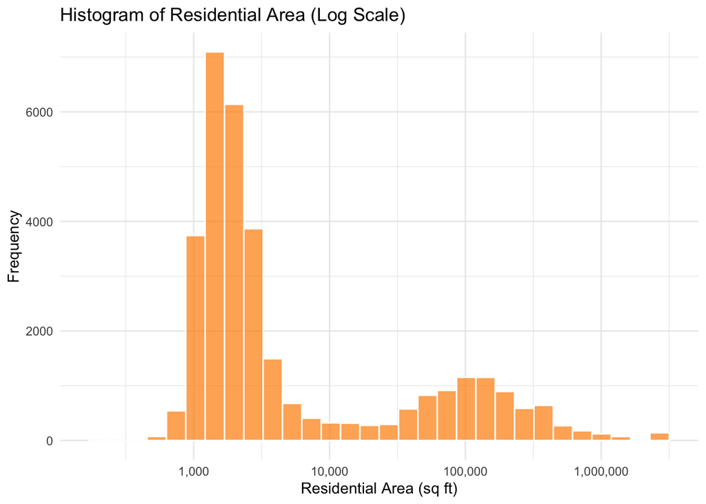

```r
ggplot(nyc %>% filter(resarea > 0), aes(x = resarea)) +
  geom_histogram(bins = 30, fill = "darkorange", color = "white", alpha = 0.7) +
  scale_x_log10(labels = scales::comma) +
  labs(title = "Histogram of Residential Area (Log Scale)",
       x = "Residential Area (sq ft)", y = "Frequency") +
  theme_minimal()
```

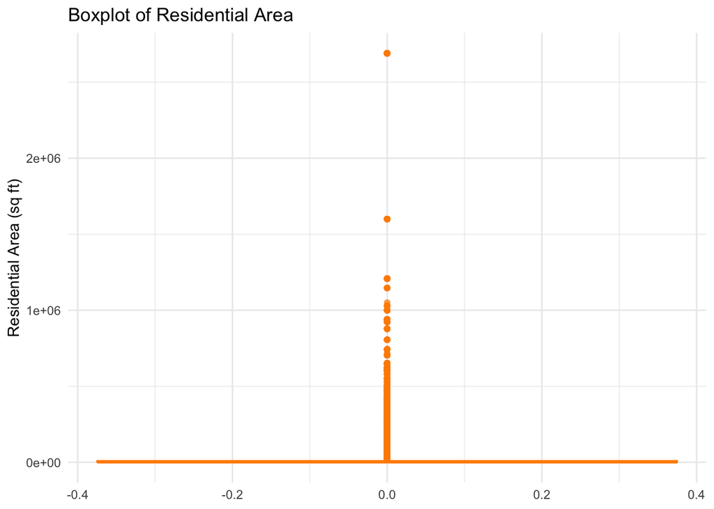

```r
ggplot(nyc, aes(y = resarea)) +
  geom_boxplot(fill = "darkorange", color = "darkorange", alpha = 0.7) +
  labs(title = "Boxplot of Residential Area",
       y = "Residential Area (sq ft)") +
  theme_minimal()
```

```r
sum(is.na(nyc$resarea))
```

```
## [1] 188
```

```r
summary(nyc$resarea)
```

```
##    Min. 1st Qu.  Median    Mean 3rd Qu.    Max.    NA's
##       0    1356    2120   55930    9816 2690565     188
```

Residential area shows severe right skew driven by high-value outliers. There are 188 NAs.

### Commercial Area

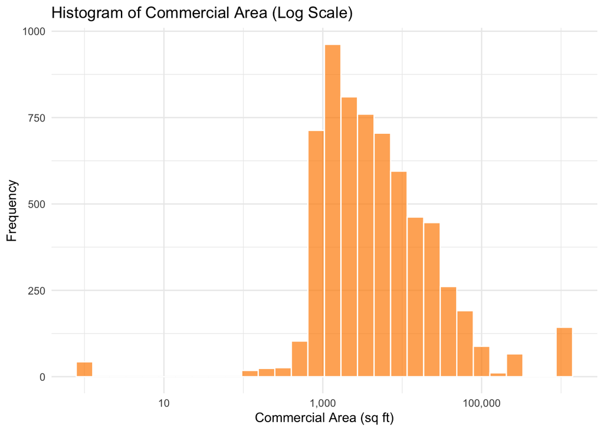

```r
ggplot(nyc %>% filter(comarea > 0), aes(x = comarea)) +
  geom_histogram(bins = 30, fill = "darkorange", color = "white", alpha = 0.7) +
  scale_x_log10(labels = scales::comma) +
  labs(title = "Histogram of Commercial Area (Log Scale)",
       x = "Commercial Area (sq ft)", y = "Frequency") +
  theme_minimal()
```

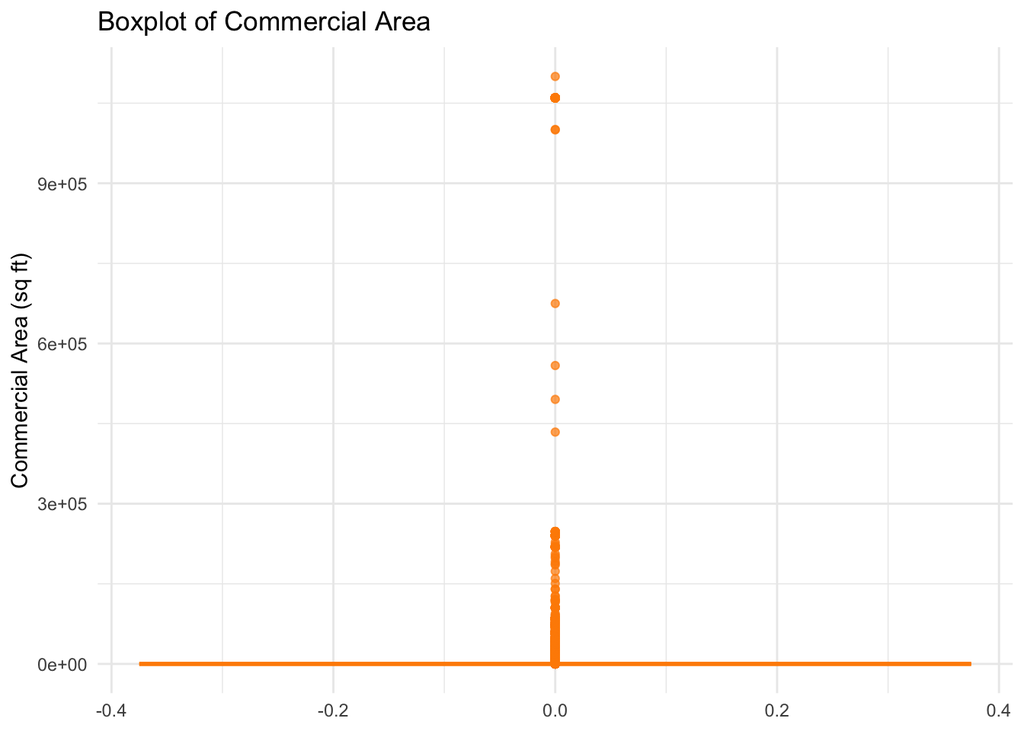

```r
ggplot(nyc, aes(y = comarea)) +
  geom_boxplot(fill = "darkorange", color = "darkorange", alpha = 0.7) +
  labs(title = "Boxplot of Commercial Area",
       y = "Commercial Area (sq ft)") +
  theme_minimal()
```

```r
sum(is.na(nyc$comarea))
```

```
## [1] 188
```

```r
summary(nyc$comarea)
```

```
##    Min. 1st Qu.  Median    Mean 3rd Qu.    Max.    NA's
##       0       0       0    6847       0 1100000     188
```

Commercial area also shows severe skew driven by high-value outliers. These are likely not data errors given NYC’s real estate market. There are 188 NAs.

### Sale Price

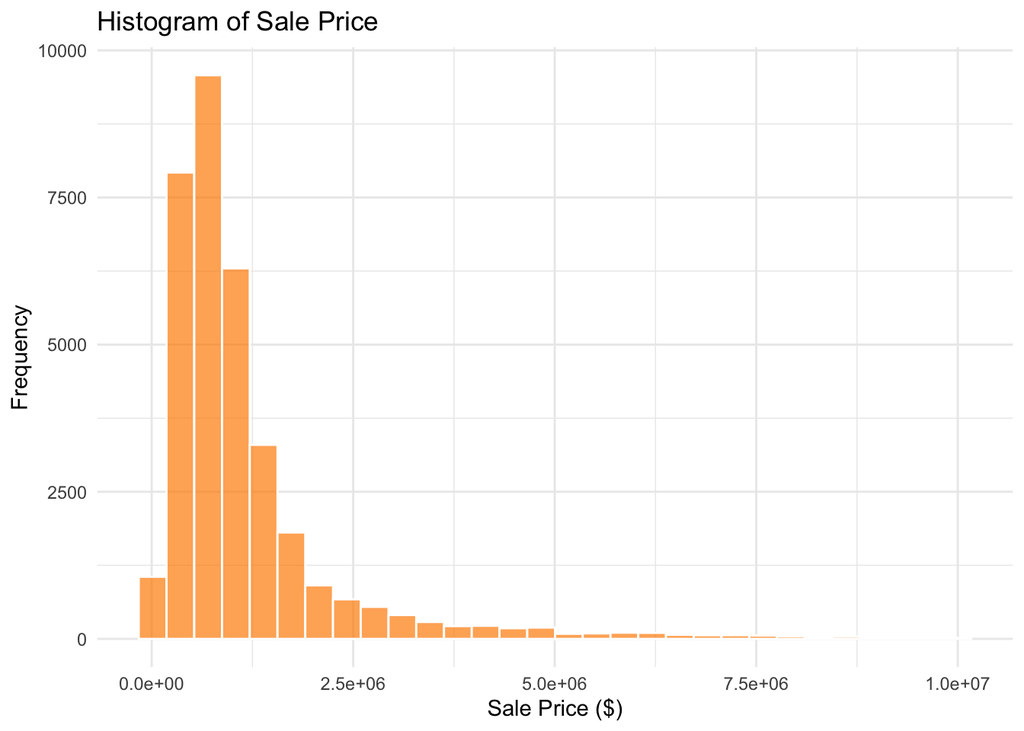

```r
ggplot(nyc, aes(x = sale_price)) +
  geom_histogram(fill = "darkorange", color = "white", alpha = 0.7) +
  labs(title = "Histogram of Sale Price",
       x = "Sale Price ($)", y = "Frequency") +
  theme_minimal()
```

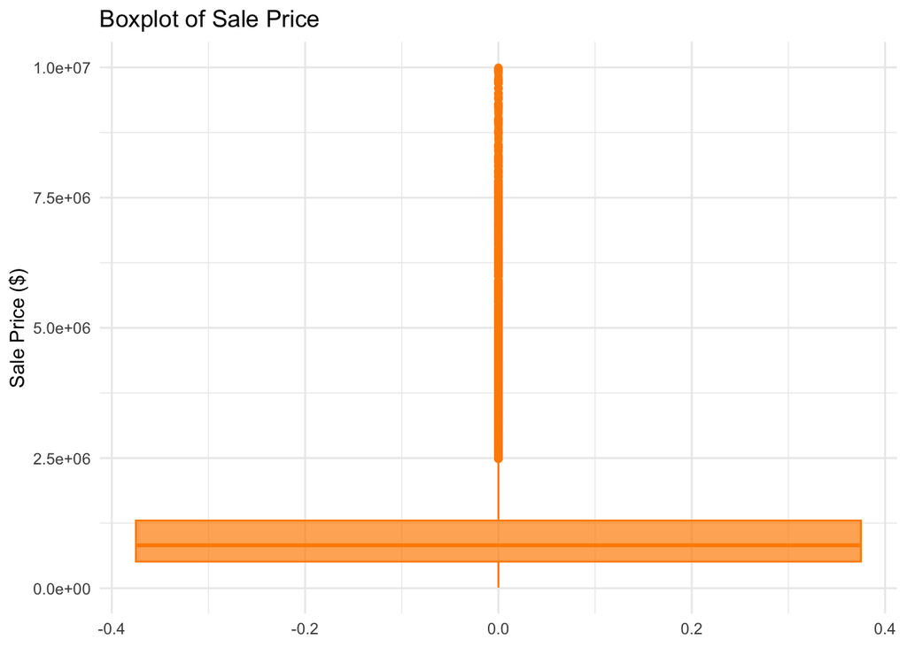

```r
ggplot(nyc, aes(y = sale_price)) +
  geom_boxplot(fill = "darkorange", color = "darkorange", alpha = 0.7) +
  labs(title = "Boxplot of Sale Price",
       y = "Sale Price ($)") +
  theme_minimal()
```

```r
summary(nyc$sale_price)
```

```
##    Min. 1st Qu.  Median    Mean 3rd Qu.    Max.
##   11863  512500  825000 1171832 1300000 9995000
```

No NAs. Right skew with high-value outliers, the highest being $9,995,000.

### Lot Area

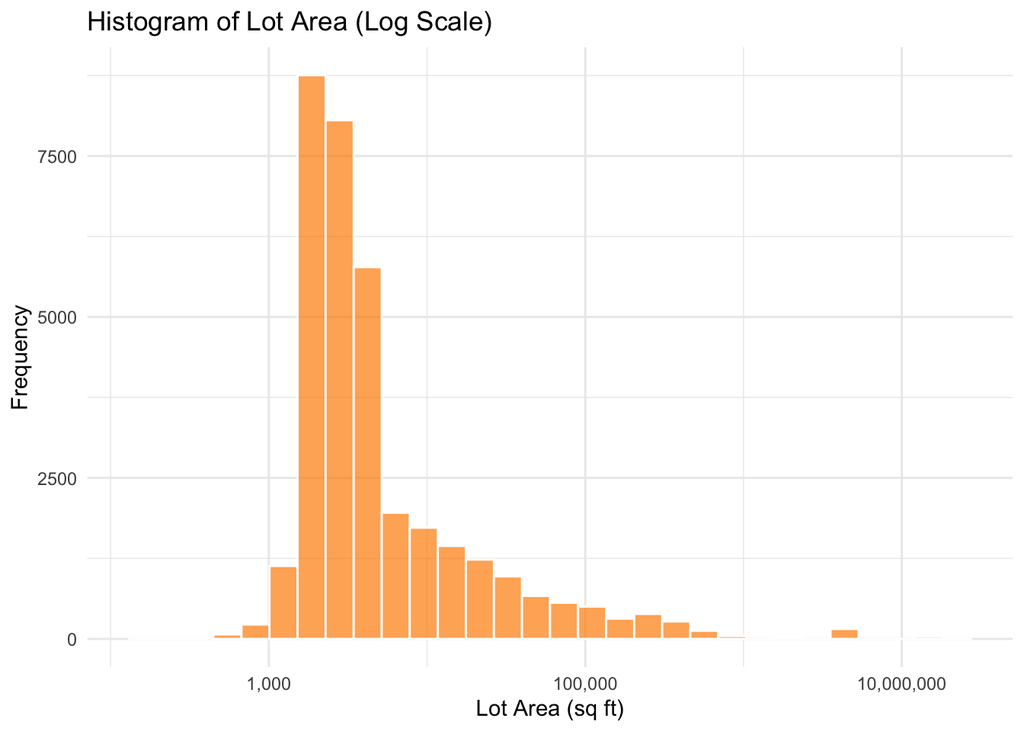

```r
ggplot(nyc %>% filter(lotarea > 0), aes(x = lotarea)) +
  geom_histogram(bins = 30, fill = "darkorange", color = "white", alpha = 0.7) +
  scale_x_log10(labels = scales::comma) +
  labs(title = "Histogram of Lot Area (Log Scale)",
       x = "Lot Area (sq ft)", y = "Frequency") +
  theme_minimal()
```

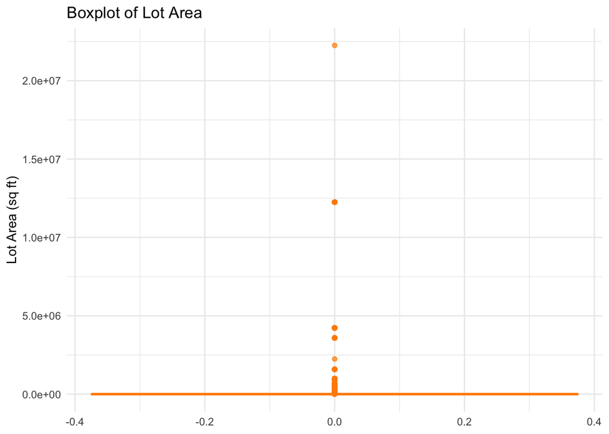

```r
ggplot(nyc, aes(y = lotarea)) +
  geom_boxplot(fill = "darkorange", color = "darkorange", alpha = 0.7) +
  labs(title = "Boxplot of Lot Area",
       y = "Lot Area (sq ft)") +
  theme_minimal()
```

```r
summary(nyc$lotarea)
```

```
##     Min.  1st Qu.   Median     Mean  3rd Qu.     Max.
##      161     2090     3090    52440     7502 22251600
```

```r
sum(is.na(nyc$lotarea))
```

```
## [1] 0
```

No NAs. Right skewed, with a maximum lot area of 22,251,600 sq ft.

### Number of Floors

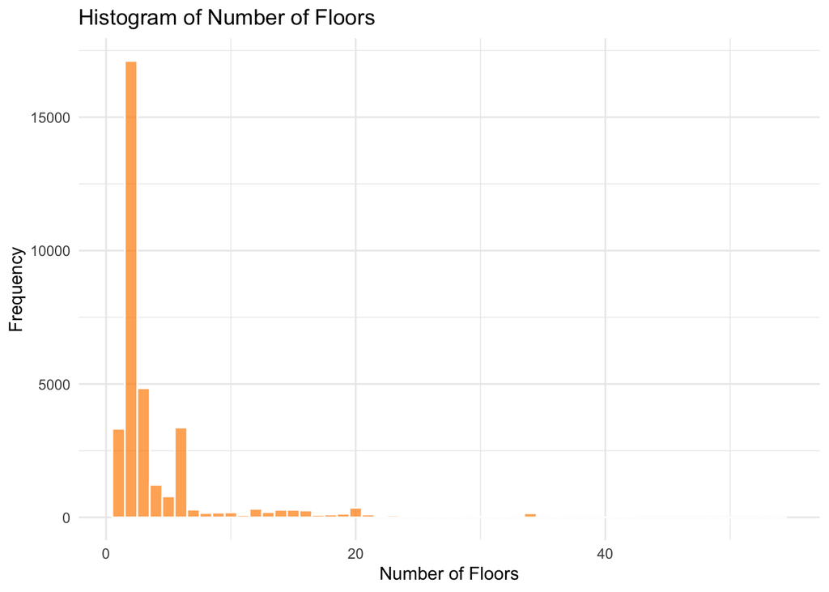

```r
ggplot(nyc, aes(x = numfloors)) +
  geom_histogram(binwidth = 1, fill = "darkorange", color = "white", alpha = 0.7) +
  labs(title = "Histogram of Number of Floors",
       x = "Number of Floors", y = "Frequency") +
  theme_minimal()
```

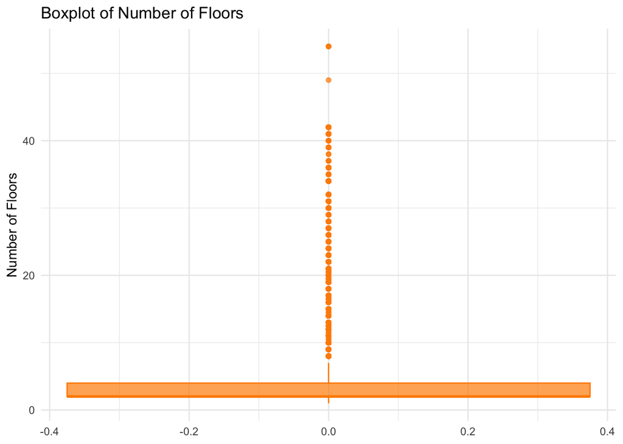

```r
ggplot(nyc, aes(y = numfloors)) +
  geom_boxplot(fill = "darkorange", color = "darkorange", alpha = 0.7) +
  labs(title = "Boxplot of Number of Floors",
       y = "Number of Floors") +
  theme_minimal()
```

```r
summary(nyc$numfloors)
```

```
##    Min. 1st Qu.  Median    Mean 3rd Qu.    Max.    NA's
##   1.000   2.000   2.000   4.228   4.000  54.000      43
```

```r
sum(is.na(nyc$numfloors))
```

```
## [1] 43
```

```r
nyc %>% filter(is.na(numfloors))
```

```
##    borough_x block  lot sale_price zip_code borough_y yearbuilt lotarea
## 1          2  4886   64     600000    10469        BX      1931    1235
## 2          2  4543   46    1825000    10467        BX      2001    2127
## 3          2  3487  139     900000    10473        BX      2011    1934
## 4          2  5624  103     975000    10464        BX      1950     161
## 5          2  3436  140     850000    10473        BX      2014    1483
## 6          2  5058   50     844390    10466        BX      1925    2316
## 7          3  6127   32    3779865    11209        BK      2008   12690
## 8          3  8432    6     982611    11234        BK      2023    2650
## 9          3  8432    7     889000    11234        BK      2023    2450
## 10         3  8432    8     840065    11234        BK      2023    2450
## 11         3  8432    9     972429    11234        BK      2023    2450
## 12         3  8845 1660     785000    11229        BK      1950    1800
## 13         3  8955  306     760000    11229        BK      1950    1785
## 14         3  6785   67    2050000    11229        BK      1950    6000
```

[output cut: 117 more lines]

43 NAs. Significant right skew with a maximum of 54 floors.

```r
missing_areas <- nyc %>% filter(is.na(resarea) & is.na(comarea))
summary(missing_areas)
```

```
##    borough_x         block            lot           sale_price
##  Min.   :1.000   Min.   :  155   Min.   :   3.0   Min.   :  85000
##  1st Qu.:2.750   1st Qu.: 2110   1st Qu.:  75.0   1st Qu.: 483750
##  Median :3.000   Median : 5008   Median :  75.0   Median : 787500
##  Mean   :3.277   Mean   : 5170   Mean   :  91.5   Mean   :1388061
##  3rd Qu.:4.000   3rd Qu.: 6337   3rd Qu.:  75.0   3rd Qu.:1436562
##  Max.   :5.000   Max.   :16253   Max.   :1660.0   Max.   :9300000
##
##     zip_code      borough_y           yearbuilt       lotarea
##  Min.   :10002   Length:188         Min.   :1848   Min.   :   161
##  1st Qu.:10462   Class :character   1st Qu.:1920   1st Qu.:  2000
##  Median :11217   Mode  :character   Median :1931   Median :  2574
##  Mean   :10938                      Mean   :1939   Mean   : 17732
##  3rd Qu.:11360                      3rd Qu.:1960   3rd Qu.:  5576
##  Max.   :11694                      Max.   :2024   Max.   :200000
##
##     bldgarea         resarea       comarea       unitsres        unitstotal
##  Min.   :     0   Min.   : NA   Min.   : NA   Min.   :  0.00   Min.   :  0.00
##  1st Qu.:  1005   1st Qu.: NA   1st Qu.: NA   1st Qu.:  1.00   1st Qu.:  1.00
##  Median :  2042   Median : NA   Median : NA   Median :  1.00   Median :  2.00
##  Mean   : 21898   Mean   :NaN   Mean   :NaN   Mean   : 18.76   Mean   : 18.94
##  3rd Qu.:  4084   3rd Qu.: NA   3rd Qu.: NA   3rd Qu.:  3.00   3rd Qu.:  4.00
##  Max.   :196000   Max.   : NA   Max.   : NA   Max.   :126.00   Max.   :126.00
##                   NA's   :188   NA's   :188
##    numfloors         latitude       longitude         landuse
##  Min.   : 1.000   Min.   :40.51   Min.   :-74.24   Min.   : 1.000
##  1st Qu.: 1.938   1st Qu.:40.64   1st Qu.:-73.98   1st Qu.: 1.000
##  Median : 2.000   Median :40.69   Median :-73.90   Median : 2.000
##  Mean   : 2.911   Mean   :40.71   Mean   :-73.92   Mean   : 3.834
##  3rd Qu.: 3.000   3rd Qu.:40.78   3rd Qu.:-73.83   3rd Qu.: 6.000
##  Max.   :10.000   Max.   :40.91   Max.   :-73.74   Max.   :11.000
##  NA's   :16       NA's   :3       NA's   :3        NA's   :1
##   bldgclass          building_age
##  Length:188         Min.   :  1.00
##  Class :character   1st Qu.: 65.00
##  Mode  :character   Median : 94.00
##                     Mean   : 86.47
##                     3rd Qu.:105.00
##                     Max.   :177.00
##
```

## Q1: EDA Part 2 — Missing Value & Outlier Handling

The 188 rows missing both residential and commercial area are removed rather than imputed. Imputing these would create imbalance and give residential area an unfair advantage in later model comparisons. Missing floor values are imputed to the median.

Outliers are not treated as data errors — NYC’s real estate market genuinely produces extreme values. However, properties beyond ±3 standard deviations are removed to keep the analysis focused on typical NYC properties and reduce undue influence on regression results.

```r
# Remove rows missing both area variables
nyc <- nyc %>%
  filter(!is.na(resarea) & !is.na(comarea))

# Impute number of floors to median
nyc$numfloors[is.na(nyc$numfloors)] <- median(nyc$numfloors, na.rm = TRUE)
summary(nyc$numfloors)
```

```
##    Min. 1st Qu.  Median    Mean 3rd Qu.    Max.
##   1.000   2.000   2.000   4.233   4.000  54.000
```

```r
# Calculate z-scores for area variables
nyc <- nyc %>%
  mutate(z_resarea = abs((resarea - mean(resarea)) / sd(resarea)),
         z_comarea = abs((comarea - mean(comarea)) / sd(comarea)),
         z_lotarea = abs((lotarea - mean(lotarea)) / sd(lotarea)))

# Check how many outliers per variable
sum(nyc$z_resarea > 3)
```

```
## [1] 415
```

```r
sum(nyc$z_comarea > 3)
```

```
## [1] 212
```

```r
sum(nyc$z_lotarea > 3)
```

```
## [1] 223
```

```r
# Remove outliers
nyc <- nyc %>%
  filter(z_resarea <= 3,
         z_comarea <= 3,
         z_lotarea <= 3)
```

## Q1: EDA Part 3 — Summary Statistics

```r
summary_table <- data.frame(
  Statistic = c("Mean", "Median", "Standard Deviation", "Minimum", "Maximum"),
  Sale_Price = c(mean(nyc$sale_price), median(nyc$sale_price), sd(nyc$sale_price),
                 min(nyc$sale_price), max(nyc$sale_price)),
  Lot_Area = c(mean(nyc$lotarea), median(nyc$lotarea), sd(nyc$lotarea),
               min(nyc$lotarea), max(nyc$lotarea)),
  Residential_Area = c(mean(nyc$resarea), median(nyc$resarea), sd(nyc$resarea),
                       min(nyc$resarea), max(nyc$resarea)),
  Commercial_Area = c(mean(nyc$comarea), median(nyc$comarea), sd(nyc$comarea),
                      min(nyc$comarea), max(nyc$comarea)),
  Number_of_Floors = c(mean(nyc$numfloors), median(nyc$numfloors), sd(nyc$numfloors),
                       min(nyc$numfloors), max(nyc$numfloors))
)

summary_table
```

```
##            Statistic Sale_Price  Lot_Area Residential_Area Commercial_Area
## 1               Mean    1178550  16713.70         36852.88        1752.572
## 2             Median     830000   3005.00          2100.00           0.000
## 3 Standard Deviation    1242363  55415.81         89576.92        7896.450
## 4            Minimum      11863    297.00             0.00           0.000
## 5            Maximum    9995000 920966.00        651914.00      206000.000
##   Number_of_Floors
## 1         4.017562
## 2         2.000000
## 3         4.701363
## 4         1.000000
## 5        54.000000
```

## Q1: Correlation Matrix

```r
cor_data <- nyc %>%
  dplyr::select(sale_price, resarea, comarea, lotarea, numfloors) %>%
  na.omit()

cor_matrix <- cor(cor_data)
print(cor_matrix)
```

```
##              sale_price    resarea    comarea    lotarea    numfloors
## sale_price  1.000000000 -0.1077970 0.03505761 -0.1302605 -0.006565251
## resarea    -0.107796975  1.0000000 0.39617247  0.6130455  0.740085040
## comarea     0.035057607  0.3961725 1.00000000  0.1240777  0.470541061
## lotarea    -0.130260515  0.6130455 0.12407772  1.0000000  0.178399507
## numfloors  -0.006565251  0.7400850 0.47054106  0.1783995  1.000000000
```

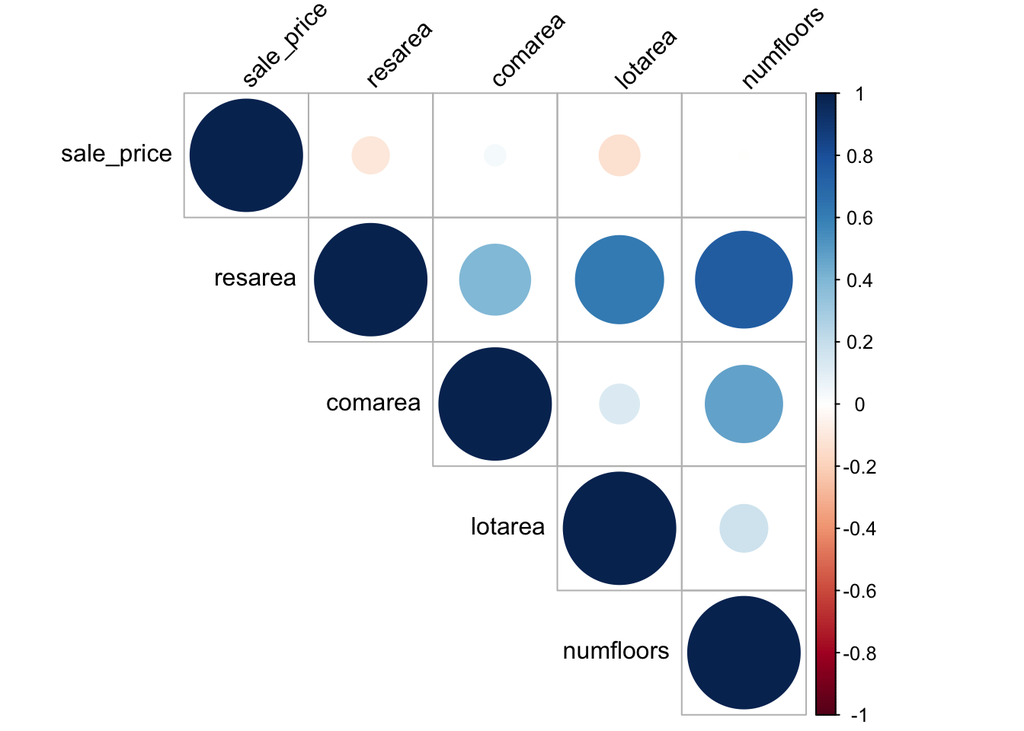

```r
corrplot(cor_matrix, method = "circle", type = "upper",
         tl.col = "black", tl.srt = 45)
```

## Q1: Scatter Plot Matrix

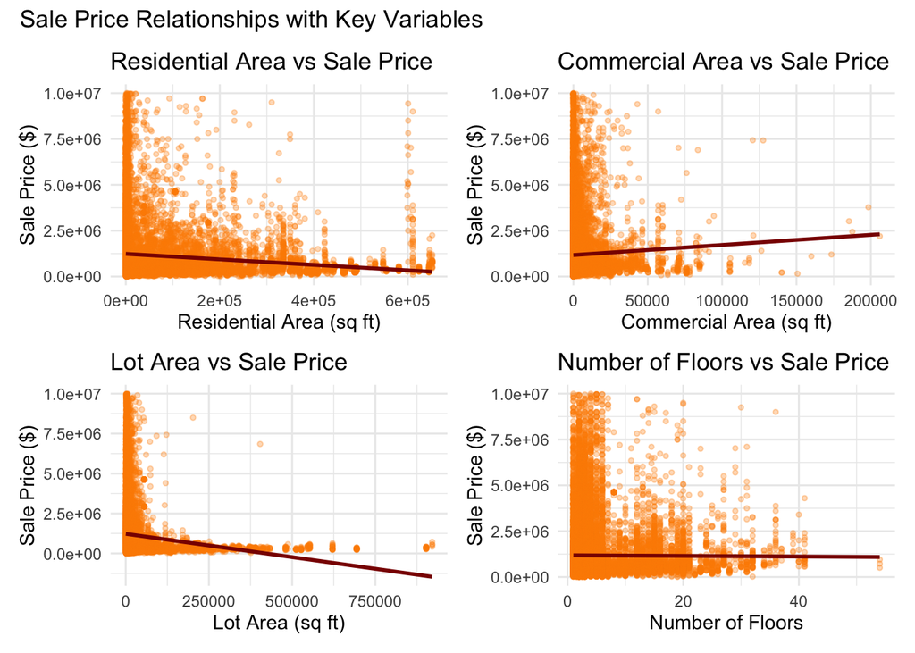

```r
p1 <- ggplot(nyc, aes(x = resarea, y = sale_price)) +
  geom_point(alpha = 0.3, color = "darkorange", size = 1) +
  geom_smooth(method = "lm", color = "darkred", se = FALSE, linewidth = 1) +
  labs(title = "Residential Area vs Sale Price",
       x = "Residential Area (sq ft)", y = "Sale Price ($)") +
  theme_minimal()

p2 <- ggplot(nyc, aes(x = comarea, y = sale_price)) +
  geom_point(alpha = 0.3, color = "darkorange", size = 1) +
  geom_smooth(method = "lm", color = "darkred", se = FALSE, linewidth = 1) +
  labs(title = "Commercial Area vs Sale Price",
       x = "Commercial Area (sq ft)", y = "Sale Price ($)") +
  theme_minimal()

p3 <- ggplot(nyc, aes(x = lotarea, y = sale_price)) +
  geom_point(alpha = 0.3, color = "darkorange", size = 1) +
  geom_smooth(method = "lm", color = "darkred", se = FALSE, linewidth = 1) +
  labs(title = "Lot Area vs Sale Price",
       x = "Lot Area (sq ft)", y = "Sale Price ($)") +
  theme_minimal()

p4 <- ggplot(nyc, aes(x = numfloors, y = sale_price)) +
  geom_point(alpha = 0.3, color = "darkorange", size = 1) +
  geom_smooth(method = "lm", color = "darkred", se = FALSE, linewidth = 1) +
  labs(title = "Number of Floors vs Sale Price",
       x = "Number of Floors", y = "Sale Price ($)") +
  theme_minimal()

(p1 | p2) / (p3 | p4) +
  plot_annotation(title = "Sale Price Relationships with Key Variables")
```

## Q1: Simple Regression — Best Subsets Selection

**α = 0.05**

```r
best_fit <- regsubsets(sale_price ~ resarea + comarea + lotarea + numfloors,
                       data = nyc, nbest = 2)

subsTable <- function(obj, scale) {
  x <- summary(best_fit)
  m <- cbind(round(x[[scale]], 3), x$which[, -1])
  colnames(m)[1] <- scale
  m[order(m[, 1]), ]
}

subsTable(best_fit, scale = "adjr2")
```

```
##   adjr2 resarea comarea lotarea numfloors
## 1 0.012       1       0       0         0
## 1 0.017       0       0       1         0
## 2 0.020       0       1       1         0
## 2 0.023       1       0       0         1
## 3 0.024       1       0       1         1
## 3 0.026       1       1       0         1
## 4 0.027       1       1       1         1
```

```r
fit1 <- lm(formula = sale_price ~ resarea + numfloors, data = nyc)
fit2 <- lm(formula = sale_price ~ comarea + numfloors, data = nyc)

summary(fit1)
```

```
##
## Call:
## lm(formula = sale_price ~ resarea + numfloors, data = nyc)
##
## Residuals:
##      Min       1Q   Median       3Q      Max
## -1760447  -622325  -348353   118259  9352357
##
## Coefficients:
##               Estimate Std. Error t value Pr(>|t|)
## (Intercept)  1.123e+06  9.056e+03  124.00   <2e-16 ***
## resarea     -3.157e+00  1.109e-01  -28.47   <2e-16 ***
## numfloors    4.278e+04  2.113e+03   20.25   <2e-16 ***
## ---
## Signif. codes:  0 '***' 0.001 '**' 0.01 '*' 0.05 '.' 0.1 ' ' 1
##
## Residual standard error: 1228000 on 33782 degrees of freedom
## Multiple R-squared:  0.02347,    Adjusted R-squared:  0.02341
## F-statistic:   406 on 2 and 33782 DF,  p-value: < 2.2e-16
```

```r
summary(fit2)
```

```
##
## Call:
## lm(formula = sale_price ~ comarea + numfloors, data = nyc)
##
## Residuals:
##      Min       1Q   Median       3Q      Max
## -2110981  -655832  -350718   119168  8829822
##
## Coefficients:
##               Estimate Std. Error t value Pr(>|t|)
## (Intercept)  1.196e+06  8.989e+03 133.105  < 2e-16 ***
## comarea      7.708e+00  9.692e-01   7.954 1.87e-15 ***
## numfloors   -7.827e+03  1.628e+03  -4.808 1.53e-06 ***
## ---
## Signif. codes:  0 '***' 0.001 '**' 0.01 '*' 0.05 '.' 0.1 ' ' 1
##
## Residual standard error: 1241000 on 33782 degrees of freedom
## Multiple R-squared:  0.001912,   Adjusted R-squared:  0.001853
## F-statistic: 32.36 on 2 and 33782 DF,  p-value: 9.122e-15
```

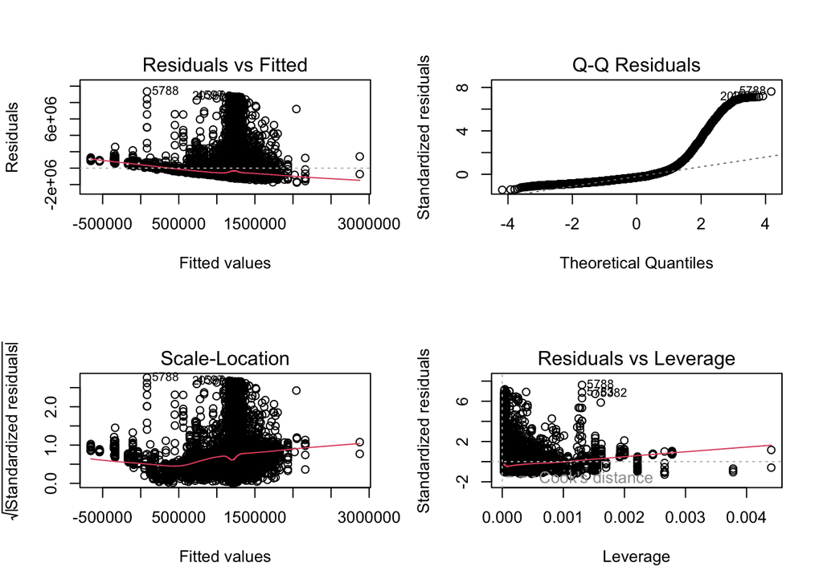

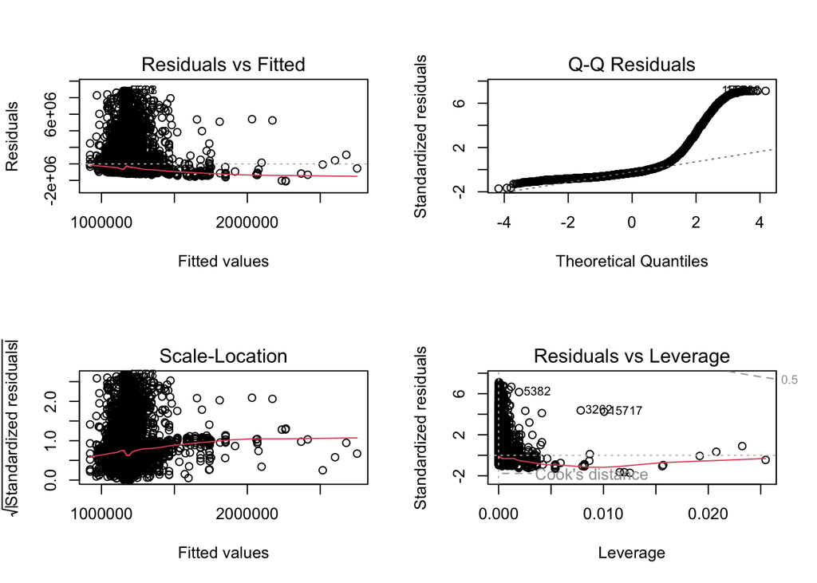

```r
par(mfrow = c(2, 2))
plot(fit1)

par(mfrow = c(2, 2))
plot(fit2)
dev.off()
```

```r
# Multicollinearity check
vif(fit1)
```

```
##   resarea numfloors
##  2.211048  2.211048
```

```r
vif(fit2)
```

```
##   comarea numfloors
##  1.284371  1.284371
```

## Q2: EDA — Land Use & Borough

```r
# Borough counts
nyc %>%
  group_by(borough_y) %>%
  summarise(count = n()) %>%
  arrange(desc(count))
```

```
## # A tibble: 5 × 2
##   borough_y count
##   <chr>     <int>
## 1 QN        12800
## 2 BK         9836
## 3 SI         3925
## 4 MN         3883
## 5 BX         3341
```

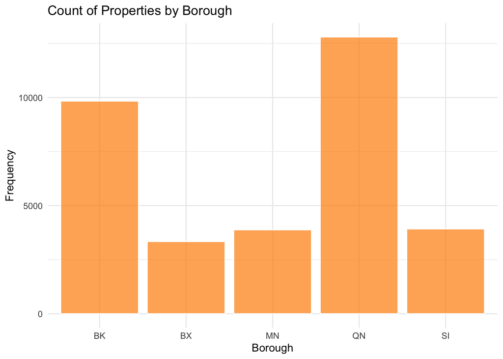

```r
# Borough bar chart
ggplot(nyc, aes(x = borough_y)) +
  geom_bar(fill = "darkorange", color = "white", alpha = 0.7) +
  labs(title = "Count of Properties by Borough",
       x = "Borough", y = "Frequency") +
  theme_minimal()
```

```r
# Land use counts
nyc %>%
  group_by(landuse) %>%
  summarise(count = n()) %>%
  arrange(desc(count))
```

```
## # A tibble: 12 × 2
##    landuse count
##      <dbl> <int>
##  1       1 18536
##  2       3  6614
##  3       2  5506
##  4       4  1722
##  5       5   688
##  6       6   303
##  7       8   205
##  8       7   139
##  9      10    67
## 10      11     2
## 11      NA     2
## 12       9     1
```

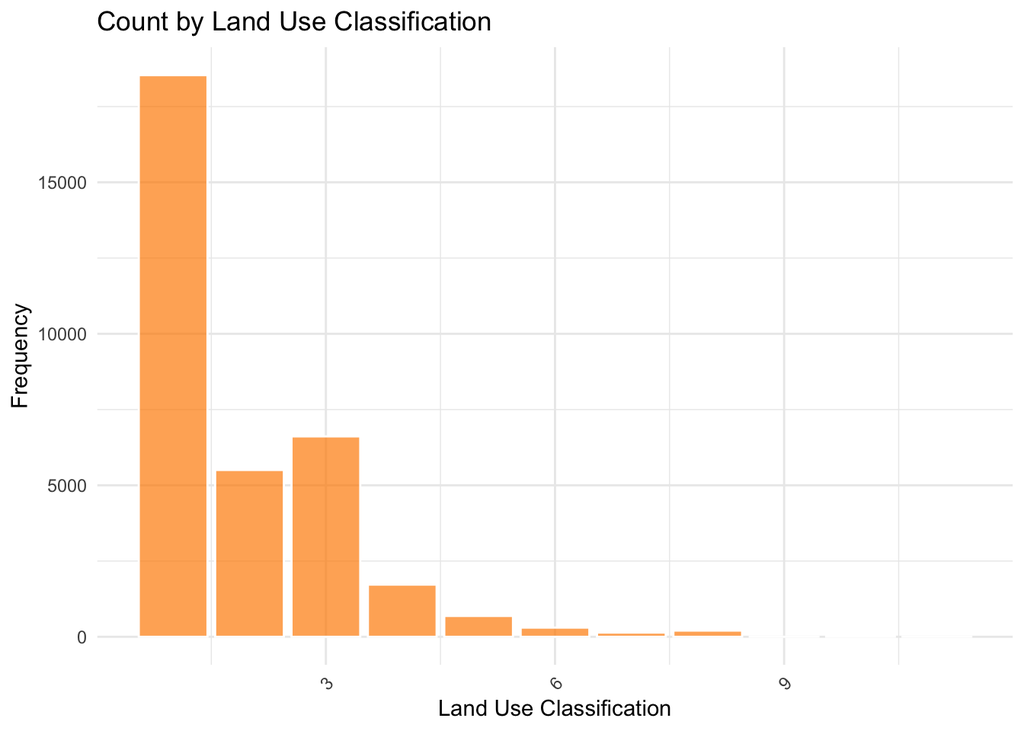

```r
# Land use bar chart
ggplot(nyc, aes(x = landuse)) +
  geom_bar(fill = "darkorange", color = "white", alpha = 0.7) +
  labs(title = "Count by Land Use Classification",
       x = "Land Use Classification", y = "Frequency") +
  theme_minimal() +
  theme(axis.text.x = element_text(angle = 45, hjust = 1))
```

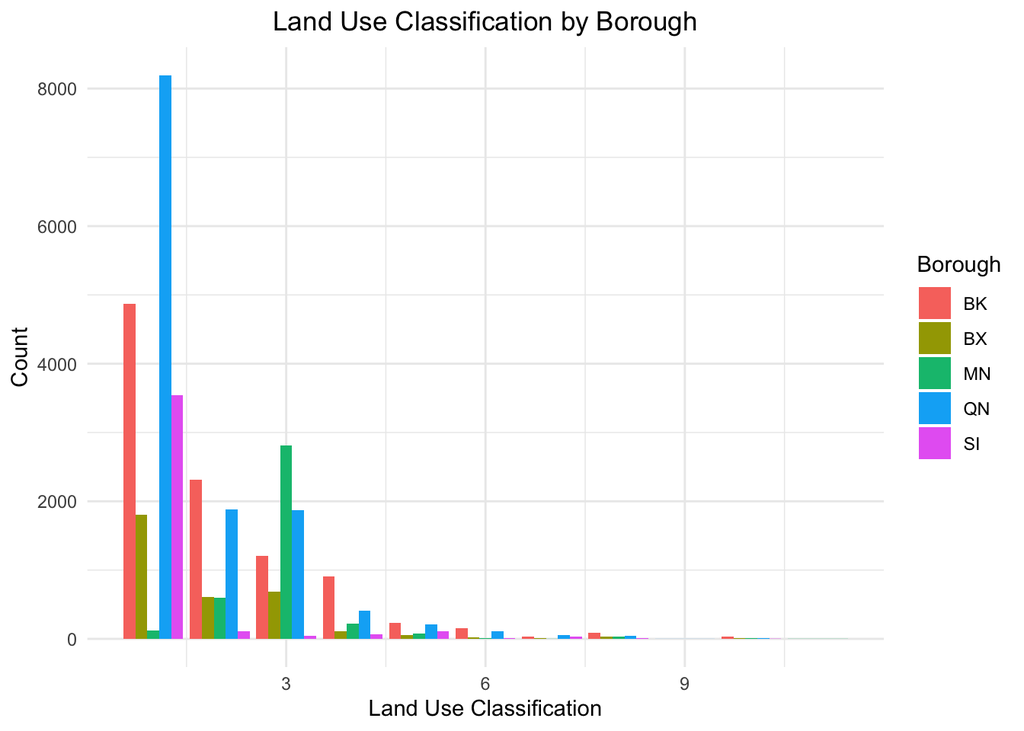

```r
bor_land_table <- nyc %>%
  group_by(landuse, borough_y) %>%
  summarise(count = n()) %>%
  arrange(landuse, borough_y)

# Grouped bar chart
ggplot(bor_land_table, aes(x = landuse, y = count, fill = borough_y)) +
  geom_bar(stat = "identity", position = "dodge") +
  labs(title = "Land Use Classification by Borough",
       x = "Land Use Classification", y = "Count", fill = "Borough") +
  theme_minimal() +
  theme(plot.title = element_text(hjust = 0.5))
```

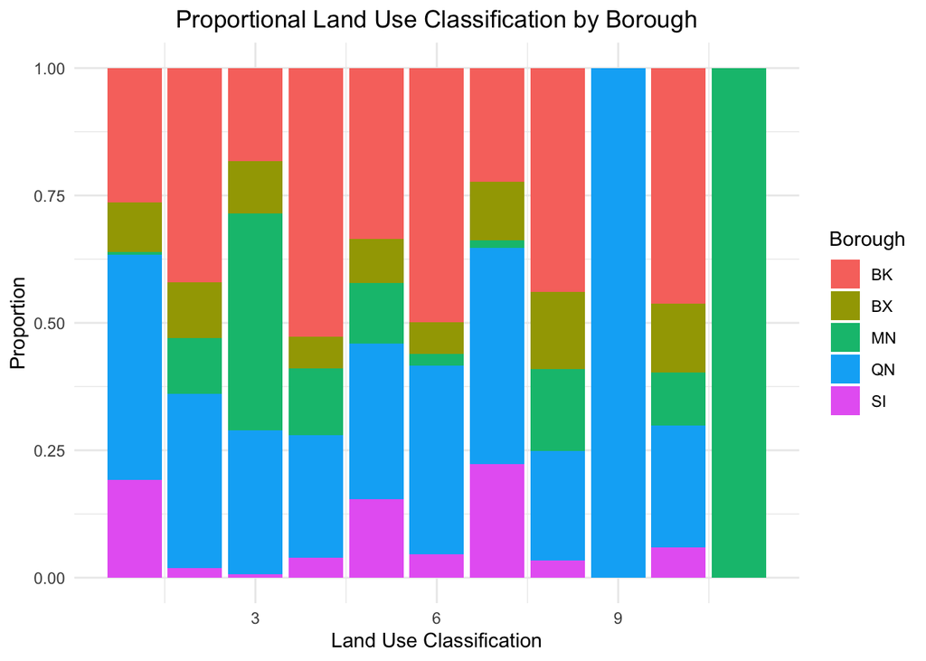

```r
# Proportional stacked bar chart
ggplot(bor_land_table, aes(x = landuse, y = count, fill = borough_y)) +
  geom_bar(stat = "identity", position = "fill") +
  labs(title = "Proportional Land Use Classification by Borough",
       x = "Land Use Classification", y = "Proportion", fill = "Borough") +
  theme_minimal() +
  theme(plot.title = element_text(hjust = 0.5))
```

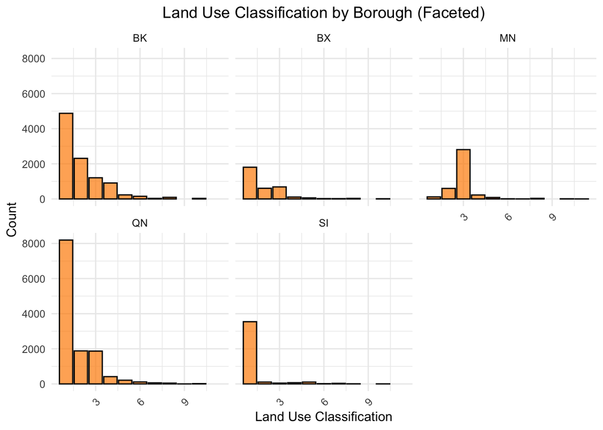

```r
# Faceted bar chart
ggplot(bor_land_table, aes(x = landuse, y = count)) +
  geom_bar(stat = "identity", fill = "darkorange", color = "black", alpha = 0.7) +
  facet_wrap(~ borough_y) +
  labs(title = "Land Use Classification by Borough (Faceted)",
       x = "Land Use Classification", y = "Count") +
  theme_minimal() +
  theme(plot.title = element_text(hjust = 0.5),
        axis.text.x = element_text(angle = 45, hjust = 1),
        legend.position = "none")
```

## Q2: Chi-Squared Independence Test

**H₀:** Land use and borough are independent **H₁:** Land use and borough are dependent **α = 0.05**

```r
bor_land_table2 <- xtabs(count ~ landuse + borough_y, data = bor_land_table)
bor_land_table2 <- bor_land_table2[rownames(bor_land_table2) != "NA",
                                    colnames(bor_land_table2) != "NA"]

# Build matrix manually
r1  <- c(4876, 1806, 117,  8193, 3544)
r2  <- c(2312,  608, 599,  1881,  106)
r3  <- c(1205,  686, 2809, 1869,   45)
r4  <- c(908,   107, 225,   414,   68)
r5  <- c(231,    59,  82,   210,  106)
r6  <- c(151,    19,   7,   112,   14)
r7  <- c(31,     16,   2,    59,   31)
r8  <- c(90,     31,  33,    44,    7)
r9  <- c(0,       0,   0,     1,    0)
r10 <- c(31,      9,   7,    16,    4)
r11 <- c(0,       0,   2,     0,    0)

bor_land_matrix <- matrix(c(r1, r2, r3, r4, r5, r6, r7, r8, r9, r10, r11),
                           nrow = 11, byrow = TRUE)
colnames(bor_land_matrix) <- c("BK", "BX", "MN", "QN", "SI")

# Degrees of freedom and critical value
df <- (nrow(bor_land_table2) - 1) * (ncol(bor_land_table2) - 1)
cv <- qchisq(0.95, df)
cat("Degrees of freedom:", df, "\nCritical value:", round(cv, 2), "\n")
```

```
## Degrees of freedom: 40
## Critical value: 55.76
```

```r
# Chi-squared test
chi_sq_test <- chisq.test(bor_land_matrix)
print(chi_sq_test)
```

```
##
##  Pearson's Chi-squared test
##
## data:  bor_land_matrix
## X-squared = 11220, df = 40, p-value < 2.2e-16
```

The chi-squared statistic of 11,220.39 far exceeds the critical value of 55.76 (df = 40, α = 0.05). We reject the null hypothesis — land use and borough are **dependent**. The distribution of land use types differs significantly across NYC boroughs.

## Q3: EDA — Residential & Commercial Area by Borough

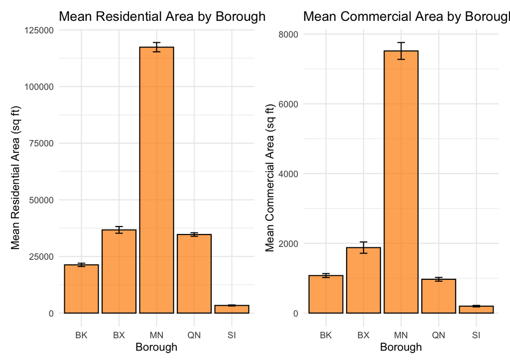

```r
# Summary tables
summary_res <- nyc %>%
  group_by(borough_y) %>%
  summarise(mean_resarea = mean(resarea, na.rm = TRUE),
            se_resarea = sd(resarea, na.rm = TRUE) / sqrt(n()))

summary_com <- nyc %>%
  group_by(borough_y) %>%
  summarise(mean_comarea = mean(comarea, na.rm = TRUE),
            se_comarea = sd(comarea, na.rm = TRUE) / sqrt(n()))

# Bar plots with error bars
p1 <- ggplot(summary_res, aes(x = borough_y, y = mean_resarea)) +
  geom_bar(stat = "identity", fill = "darkorange", color = "black", alpha = 0.7) +
  geom_errorbar(aes(ymin = mean_resarea - se_resarea,
                    ymax = mean_resarea + se_resarea), width = 0.2) +
  labs(title = "Mean Residential Area by Borough",
       x = "Borough", y = "Mean Residential Area (sq ft)") +
  theme_minimal()

p2 <- ggplot(summary_com, aes(x = borough_y, y = mean_comarea)) +
  geom_bar(stat = "identity", fill = "darkorange", color = "black", alpha = 0.7) +
  geom_errorbar(aes(ymin = mean_comarea - se_comarea,
                    ymax = mean_comarea + se_comarea), width = 0.2) +
  labs(title = "Mean Commercial Area by Borough",
       x = "Borough", y = "Mean Commercial Area (sq ft)") +
  theme_minimal()

p1 | p2
```

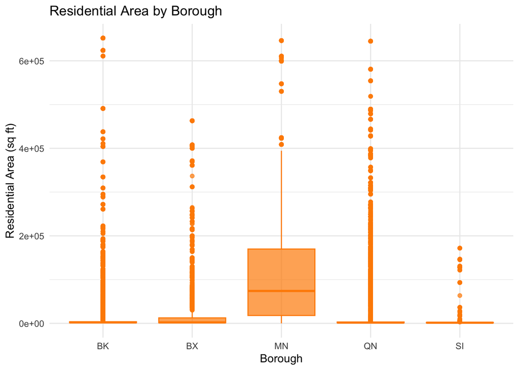

```r
# Boxplots
ggplot(nyc, aes(x = borough_y, y = resarea)) +
  geom_boxplot(fill = "darkorange", color = "darkorange", alpha = 0.7) +
  labs(title = "Residential Area by Borough",
       x = "Borough", y = "Residential Area (sq ft)") +
  theme_minimal()
```

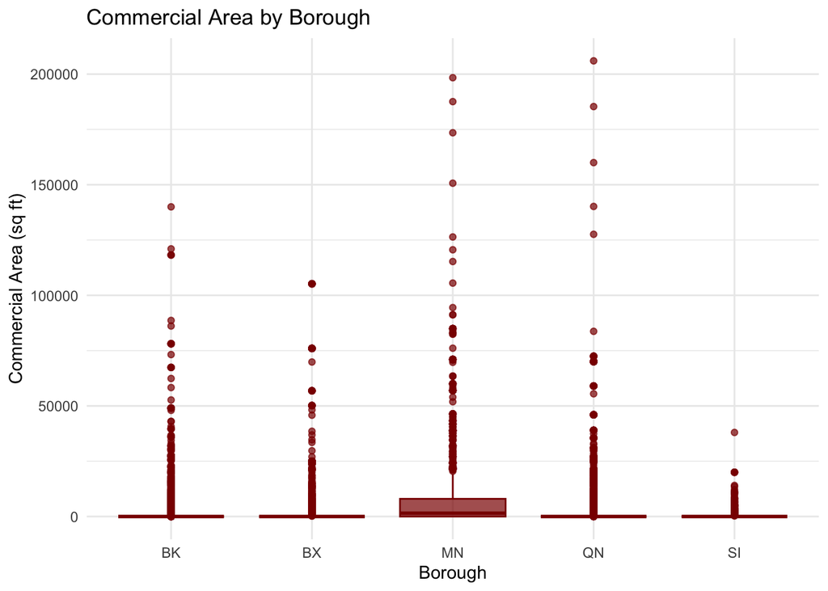

```r
ggplot(nyc, aes(x = borough_y, y = comarea)) +
  geom_boxplot(fill = "darkred", color = "darkred", alpha = 0.7) +
  labs(title = "Commercial Area by Borough",
       x = "Borough", y = "Commercial Area (sq ft)") +
  theme_minimal()
```

```r
# Summary table
summary_res %>%
  left_join(summary_com, by = "borough_y") %>%
  dplyr::select(borough_y, mean_resarea, mean_comarea)
```

```
## # A tibble: 5 × 3
##   borough_y mean_resarea mean_comarea
##   <chr>            <dbl>        <dbl>
## 1 BK              21296.        1076.
## 2 BX              36725.        1877.
## 3 MN             117375.        7515.
## 4 QN              34681.         969.
## 5 SI               3369.         199.
```

## Q3: One-Way ANOVA Tests

**α = 0.05 for both tests**

### Residential Area

**H₀:** Mean residential area is equal across all boroughs **H₁:** At least one borough differs in mean residential area

```r
anova_resarea <- aov(resarea ~ borough_y, data = nyc)
summary(anova_resarea)
```

```
##                Df    Sum Sq   Mean Sq F value Pr(>F)
## borough_y       4 3.202e+13 8.004e+12    1131 <2e-16 ***
## Residuals   33780 2.391e+14 7.077e+09
## ---
## Signif. codes:  0 '***' 0.001 '**' 0.01 '*' 0.05 '.' 0.1 ' ' 1
```

```r
dfres1 <- length(unique(nyc$borough_y)) - 1
dfres2 <- nrow(nyc) - length(unique(nyc$borough_y))
critical_value_res <- qf(1 - 0.05, df1 = dfres1, df2 = dfres2)
cat("Critical value (residential):", round(critical_value_res, 2), "\n")
```

```
## Critical value (residential): 2.37
```

### Commercial Area

**H₀:** Mean commercial area is equal across all boroughs **H₁:** At least one borough differs in mean commercial area

```r
anova_comarea <- aov(comarea ~ borough_y, data = nyc)
summary(anova_comarea)
```

```
##                Df    Sum Sq  Mean Sq F value Pr(>F)
## borough_y       4 1.508e+11 3.77e+10   651.2 <2e-16 ***
## Residuals   33780 1.956e+12 5.79e+07
## ---
## Signif. codes:  0 '***' 0.001 '**' 0.01 '*' 0.05 '.' 0.1 ' ' 1
```

```r
dfcom1 <- length(unique(nyc$borough_y)) - 1
dfcom2 <- nrow(nyc) - length(unique(nyc$borough_y))
critical_value_com <- qf(1 - 0.05, df1 = dfcom1, df2 = dfcom2)
cat("Critical value (commercial):", round(critical_value_com, 2), "\n")
```

```
## Critical value (commercial): 2.37
```

## Q3: Tukey HSD Post-Hoc Tests

### Residential Area

```r
tukey_resarea <- TukeyHSD(anova_resarea)
tukey_resarea
```

```
##   Tukey multiple comparisons of means
##     95% family-wise confidence level
##
## Fit: aov(formula = resarea ~ borough_y, data = nyc)
##
## $borough_y
##              diff         lwr         upr     p adj
## BX-BK   15428.494   10833.360   20023.627 0.0000000
## MN-BK   96078.486   91729.323  100427.648 0.0000000
## QN-BK   13385.283   10308.315   16462.251 0.0000000
## SI-BK  -17927.282  -22259.729  -13594.835 0.0000000
## MN-BX   80649.992   75234.920   86065.065 0.0000000
## QN-BX   -2043.211   -6501.409    2414.987 0.7217637
## SI-BX  -33355.775  -38757.432  -27954.119 0.0000000
## QN-MN  -82693.203  -86897.426  -78488.980 0.0000000
## SI-MN -114005.768 -119199.789 -108811.746 0.0000000
## SI-QN  -31312.565  -35499.494  -27125.636 0.0000000
```

**Decision:** F = 1131 > critical value of 2.37 (p < 2e-16). Reject H₀. Significant differences in mean residential area exist across boroughs. Manhattan has significantly more residential area than all other boroughs. Queens and Bronx are the only pair with no significant difference (p = 0.72).

### Commercial Area

```r
tukey_comarea <- TukeyHSD(anova_comarea)
tukey_comarea
```

```
##   Tukey multiple comparisons of means
##     95% family-wise confidence level
##
## Fit: aov(formula = comarea ~ borough_y, data = nyc)
##
## $borough_y
##             diff        lwr        upr     p adj
## BX-BK   801.4625   385.8429  1217.0821 0.0000014
## MN-BK  6438.7654  6045.3933  6832.1374 0.0000000
## QN-BK  -107.0684  -385.3733   171.2364 0.8321992
## SI-BK  -877.0223 -1268.8825  -485.1621 0.0000000
## MN-BX  5637.3028  5147.5216  6127.0841 0.0000000
## QN-BX  -908.5310 -1311.7650  -505.2969 0.0000000
## SI-BX -1678.4848 -2167.0526 -1189.9170 0.0000000
## QN-MN -6545.8338 -6926.0964 -6165.5712 0.0000000
## SI-MN -7315.7876 -7785.5753 -6845.9999 0.0000000
## SI-QN  -769.9538 -1148.6522  -391.2554 0.0000003
```

**Decision:** F = 651.2 > critical value of 2.37 (p < 2e-16). Reject H₀. Significant differences in mean commercial area exist across boroughs. Manhattan has significantly more commercial area than all other boroughs. Queens and Brooklyn are the only pair with no significant difference (p = 0.83).

## Q4: Multiple Linear Regression — Stepwise Selection

```r
set.seed(123)

# 70/30 train/test split
train_index <- createDataPartition(nyc$sale_price, p = 0.7, list = FALSE)
caret_train <- nyc[train_index, ]
caret_test  <- nyc[-train_index, ]

# Full model with area and location variables
full_model_location <- lm(sale_price ~ resarea + comarea + lotarea + numfloors +
                            borough_y + factor(landuse),
                          data = caret_train)
summary(full_model_location)
```

```
##
## Call:
## lm(formula = sale_price ~ resarea + comarea + lotarea + numfloors +
##     borough_y + factor(landuse), data = caret_train)
##
## Residuals:
##      Min       1Q   Median       3Q      Max
## -2616264  -533959  -244920   132613  9246461
##
## Coefficients:
##                     Estimate Std. Error t value Pr(>|t|)
## (Intercept)        1.266e+06  1.834e+04  69.061  < 2e-16 ***
## resarea            3.129e-02  1.999e-01   0.157  0.87561
## comarea           -2.356e+00  1.190e+00  -1.980  0.04770 *
## lotarea           -1.825e+00  2.133e-01  -8.559  < 2e-16 ***
## numfloors          1.604e+04  3.517e+03   4.560 5.14e-06 ***
## borough_yBX       -3.031e+05  2.834e+04 -10.698  < 2e-16 ***
## borough_yMN        4.973e+05  3.320e+04  14.980  < 2e-16 ***
## borough_yQN       -2.296e+05  1.942e+04 -11.819  < 2e-16 ***
## borough_ySI       -2.946e+05  2.778e+04 -10.606  < 2e-16 ***
## factor(landuse)2   1.129e+05  2.297e+04   4.913 9.03e-07 ***
## factor(landuse)3  -5.689e+05  3.248e+04 -17.513  < 2e-16 ***
## factor(landuse)4   5.546e+05  3.604e+04  15.389  < 2e-16 ***
## factor(landuse)5   9.232e+05  5.678e+04  16.260  < 2e-16 ***
## factor(landuse)6   1.123e+06  8.665e+04  12.956  < 2e-16 ***
## factor(landuse)7   6.781e+05  1.181e+05   5.743 9.42e-09 ***
## factor(landuse)8   6.698e+05  9.920e+04   6.752 1.49e-11 ***
## factor(landuse)9   6.537e+06  1.178e+06   5.550 2.89e-08 ***
## factor(landuse)10  5.870e+05  1.819e+05   3.226  0.00126 **
## factor(landuse)11 -1.288e+06  8.312e+05  -1.550  0.12115
## ---
## Signif. codes:  0 '***' 0.001 '**' 0.01 '*' 0.05 '.' 0.1 ' ' 1
##
## Residual standard error: 1175000 on 23630 degrees of freedom
##   (1 observation deleted due to missingness)
## Multiple R-squared:  0.09834,    Adjusted R-squared:  0.09765
## F-statistic: 143.2 on 18 and 23630 DF,  p-value: < 2.2e-16
```

```r
# Stepwise selection (both directions)
stepwise_location <- stepAIC(full_model_location, direction = "both", trace = FALSE)
summary(stepwise_location)
```

```
##
## Call:
## lm(formula = sale_price ~ comarea + lotarea + numfloors + borough_y +
##     factor(landuse), data = caret_train)
##
## Residuals:
##      Min       1Q   Median       3Q      Max
## -2622504  -534268  -244850   133099  9246262
##
## Coefficients:
##                     Estimate Std. Error t value Pr(>|t|)
## (Intercept)        1.266e+06  1.789e+04  70.769  < 2e-16 ***
## comarea           -2.330e+00  1.179e+00  -1.977  0.04802 *
## lotarea           -1.802e+00  1.535e-01 -11.738  < 2e-16 ***
## numfloors          1.635e+04  2.882e+03   5.676 1.40e-08 ***
## borough_yBX       -3.032e+05  2.833e+04 -10.704  < 2e-16 ***
## borough_yMN        4.962e+05  3.249e+04  15.271  < 2e-16 ***
## borough_yQN       -2.296e+05  1.942e+04 -11.821  < 2e-16 ***
## borough_ySI       -2.947e+05  2.778e+04 -10.609  < 2e-16 ***
## factor(landuse)2   1.126e+05  2.292e+04   4.913 9.01e-07 ***
## factor(landuse)3  -5.674e+05  3.105e+04 -18.276  < 2e-16 ***
## factor(landuse)4   5.544e+05  3.602e+04  15.391  < 2e-16 ***
## factor(landuse)5   9.228e+05  5.673e+04  16.267  < 2e-16 ***
## factor(landuse)6   1.122e+06  8.662e+04  12.956  < 2e-16 ***
## factor(landuse)7   6.782e+05  1.181e+05   5.744 9.37e-09 ***
## factor(landuse)8   6.692e+05  9.912e+04   6.751 1.50e-11 ***
## factor(landuse)9   6.528e+06  1.176e+06   5.549 2.90e-08 ***
## factor(landuse)10  5.869e+05  1.819e+05   3.226  0.00126 **
## factor(landuse)11 -1.288e+06  8.312e+05  -1.550  0.12126
## ---
## Signif. codes:  0 '***' 0.001 '**' 0.01 '*' 0.05 '.' 0.1 ' ' 1
##
## Residual standard error: 1175000 on 23631 degrees of freedom
##   (1 observation deleted due to missingness)
## Multiple R-squared:  0.09834,    Adjusted R-squared:  0.09769
## F-statistic: 151.6 on 17 and 23631 DF,  p-value: < 2.2e-16
```

```r
# Predictions on test set
preds_test_location <- predict(stepwise_location, newdata = caret_test)
valid_predictions <- !is.na(preds_test_location)
preds_test_clean  <- preds_test_location[valid_predictions]

rmse_location <- sqrt(mean((caret_test$sale_price - preds_test_location)^2, na.rm = TRUE))
r2_location   <- summary(stepwise_location)$adj.r.squared

# Test R-squared
ss_res   <- sum((caret_test$sale_price[valid_predictions] - preds_test_clean)^2)
ss_tot   <- sum((caret_test$sale_price[valid_predictions] - mean(caret_test$sale_price[valid_predictions]))^2)
test_r2  <- 1 - (ss_res / ss_tot)

cat("Test R²:", round(test_r2, 4), "\n")
```

```
## Test R²: 0.0945
```

```r
cat("=== Model Comparison ===\n")
```

```
## === Model Comparison ===
```

```r
cat("Area-only model:\n")
```

```
## Area-only model:
```

```r
cat("  Adjusted R²: 0.0235 (2.35%)\n\n")
```

```
##   Adjusted R²: 0.0235 (2.35%)
```

```r
cat("Stepwise with Borough + Land Use:\n")
```

```
## Stepwise with Borough + Land Use:
```

```r
cat("  Test RMSE:", round(rmse_location, 2), "\n")
```

```
##   Test RMSE: 1194841
```

```r
cat("  Adjusted R²:", round(r2_location, 4), "\n\n")
```

```
##   Adjusted R²: 0.0977
```

```r
cat("Improvement:\n")
```

```
## Improvement:
```

```r
cat("  R² increase:", round(r2_location - 0.0235, 4), "\n")
```

```
##   R² increase: 0.0742
```

```r
cat("  Observations used:", sum(valid_predictions), "out of", length(preds_test_location), "\n")
```

```
##   Observations used: 10134 out of 10135
```